# Dada2_LoPresti2019

# Import library

```r
library(dada2)
packageVersion("dada2") # check dada2 version
```

```
## [1] '1.21.0'
```

```r
library(Biostrings)
library(ShortRead)
library(seqTools) # per base sequence content
library(phyloseq)
library(ggplot2)
library(data.table)
library(plyr)
library(dplyr)
library(qckitfastq) # per base sequence content
library(stringr)
```

## QUALITY CHECK

First, we import the fastq files containing the raw reads. The samples were downloaded from the ENA database with the accession number PRJNA391149.

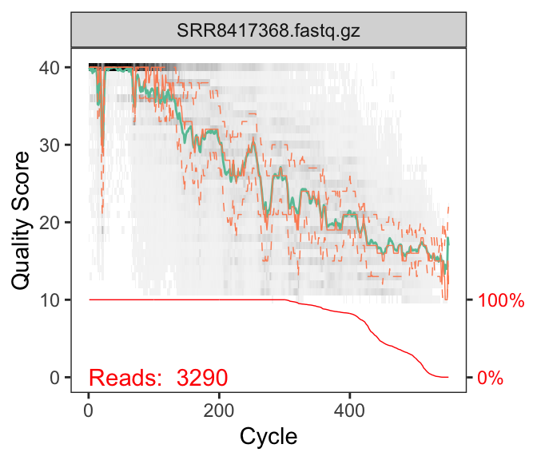

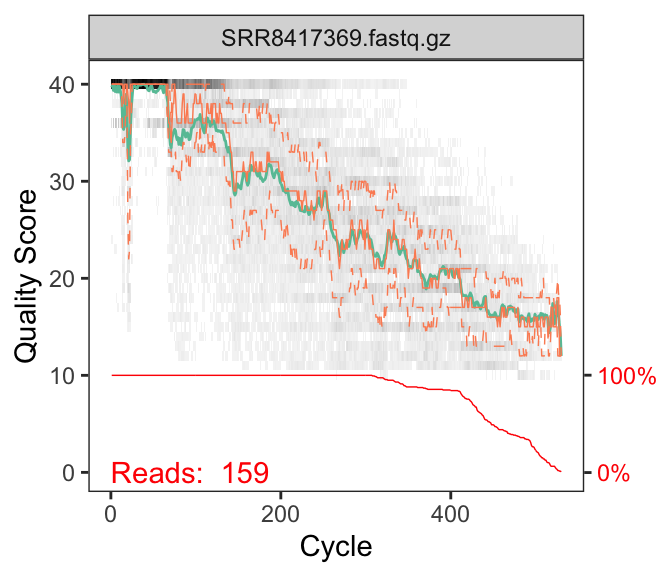

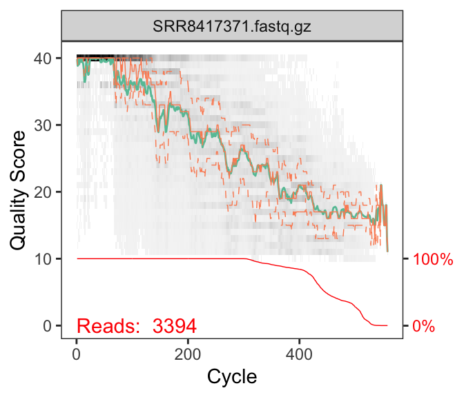

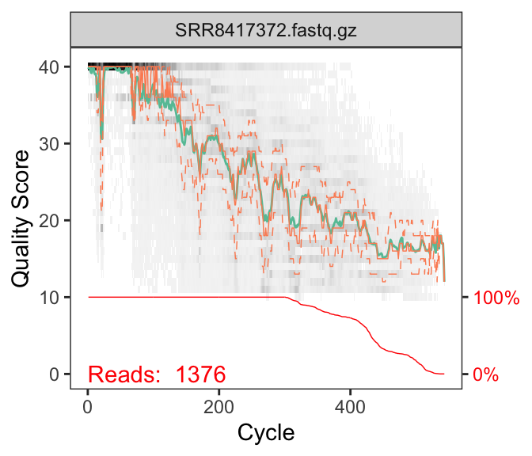

```r
# Save the path to the directory containing the fastq zipped files
path <- "~/Projects/IBS_Meta-analysis_16S/data/analysis-individual/LoPresti-2019"
# list.files(path) # check we are in the right directory

# fastq filenames have format: SAMPLENAME.fastq.gz
# Saves the whole directory path to each file name
FNs <- sort(list.files(file.path(path, "original"), pattern=".fastq.gz", full.names = TRUE))
show(FNs[1:5])

# Extract sample names, assuming filenames have format: SAMPLENAME.fastq.gz
sample.names <- sapply(strsplit(basename(FNs), "_"), `[`, 1)
show(sample.names[1:5]) # saves only the file name (without the path)

# Look at quality of all files
for (i in 3:6){ # 1:length(FNs)
  show(plotQualityProfile(FNs[i]))
}
```

```r
# Look at nb of reads per sample
# raw_stats <- data.frame('sample' = sample.names,
#                         'reads' = fastqq(FNs)@nReads)
# min(raw_stats$reads)
# max(raw_stats$reads)
# mean(raw_stats$reads)
```

We will have a quick peak at the per base sequence content of the reads in some samples, to make sure there is no anomaly (i.e. all reads having the same sequence).

```r
# Look at per base sequence content
fseq <- seqTools::fastqq(FNs[10])
```

```
## [fastqq] File ( 1/1) '/Users/scarcy/Projects/IBS_Meta-analysis_16S/data/analysis-individual/LoPresti-2019/original/SRR8417376.fastq.gz'  done.
```

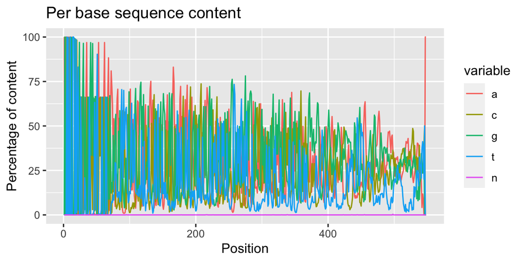

```r
rc <- read_content(fseq)
plot_read_content(rc) + labs(title = "Per base sequence content")
```

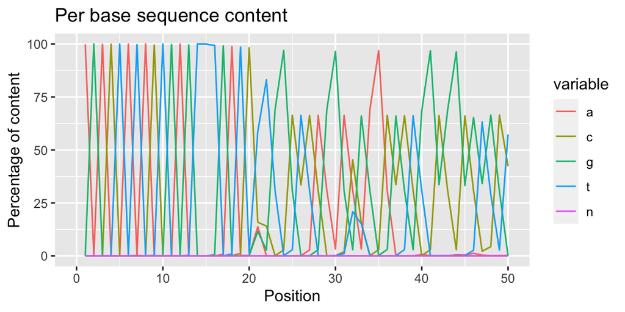

```r
plot_read_content(rc) + xlim(0,50) + labs(title = "Per base sequence content")
```

## LOOK FOR PRIMERS

Now, we will look whether the reads still contain the primers. In the paper, they describe using the V1-V3 primers, as in the article *“Remake” by High-Throughput Sequencing of the Microbiota Involved in the Production of Water Buffalo Mozzarella Chees* (Ercolini et al. 2012). Material&Methods in this article provide the primers sequences.

```r
# V1-V3
FWD <- "TTTGATCNTGGCTCAG"  # 28F primer sequence
REV <- "GTNTTACNGCGGCKGCTG" # 519R primer sequence

# Function that, from the primer sequence, will return all combinations possible (complement, reverse complement, ...)
allOrients <- function(primer) {
    # Create all orientations of the input sequence
    require(Biostrings)
    dna <- DNAString(primer)  # The Biostrings works w/ DNAString objects rather than character vectors
    orients <- c(Forward = dna, Complement = complement(dna), Reverse = reverse(dna),
        RevComp = reverseComplement(dna))
    return(sapply(orients, toString))
}

# Get all combinations of the primer sequences
FWD.orients <- allOrients(FWD) # 28F
REV.orients <- allOrients(REV) # 519R
FWD.orients # sanity check
```

```
##            Forward         Complement            Reverse            RevComp
## "TTTGATCNTGGCTCAG" "AAACTAGNACCGAGTC" "GACTCGGTNCTAGTTT" "CTGAGCCANGATCAAA"
```

```r
REV.orients
```

```
##              Forward           Complement              Reverse
## "GTNTTACNGCGGCKGCTG" "CANAATGNCGCCGMCGAC" "GTCGKCGGCGNCATTNTG"
##              RevComp
## "CAGCMGCCGCNGTAANAC"
```

```r
# Function that counts number of reads in which a sequence is found
primerHits <- function(primer, fn) {
    nhits <- vcountPattern(primer, sread(readFastq(fn)), fixed = FALSE, max.mismatch = 2)
    return(sum(nhits > 0))
}

# Get a table to know how many times the 28F and 519R primers are found in the reads of each sample
for (i in 1:6){
  cat("SAMPLE", sample.names[i], "with total number of", raw_stats[i,'reads'], "reads\n\n")
  x <-  rbind(ForwardPrimer = sapply(FWD.orients, primerHits, fn = FNs[[i]]),
              ReversePrimer = sapply(REV.orients, primerHits, fn = FNs[[i]]))
  print(x)
  cat("\n____________________________________________\n\n")
}
```

```
## SAMPLE SRR8417365.fastq.gz with total number of 206 reads
##
##               Forward Complement Reverse RevComp
## ForwardPrimer     205          0       0       1
## ReversePrimer       0          0       0       0
##
## ____________________________________________
##
## SAMPLE SRR8417366.fastq.gz with total number of 460 reads
##
##               Forward Complement Reverse RevComp
## ForwardPrimer     456          0       0       0
## ReversePrimer       0          0       0       0
##
## ____________________________________________
##
## SAMPLE SRR8417368.fastq.gz with total number of 3290 reads
##
##               Forward Complement Reverse RevComp
## ForwardPrimer    2323          0       0      16
## ReversePrimer       0          0       0     139
##
## ____________________________________________
##
## SAMPLE SRR8417369.fastq.gz with total number of 159 reads
##
##               Forward Complement Reverse RevComp
## ForwardPrimer     116          0       0       0
## ReversePrimer       0          0       0       5
##
## ____________________________________________
##
## SAMPLE SRR8417371.fastq.gz with total number of 3394 reads
##
##               Forward Complement Reverse RevComp
## ForwardPrimer    3119          0       0       4
## ReversePrimer       0          0       0     177
##
## ____________________________________________
##
## SAMPLE SRR8417372.fastq.gz with total number of 1376 reads
##
##               Forward Complement Reverse RevComp
## ForwardPrimer     911          0       0       5
## ReversePrimer       0          0       0      38
##
## ____________________________________________
```

## FILTER AND TRIM

### 1. Primer removal

The reads indeed contain the forward primer. We will keep only reads containing the primer, and then trim the primer!

```r
# KEEP READS WITH PRIMER AND REMOVE PRIMER+BARCODE
# Place filtered files in a filtered/ subdirectory
filt1_samples <- file.path(path, "filtered1", paste0(sample.names, "_filt.fastq.gz"))
# Assign names for the filtered fastq.gz files
names(filt1_samples) <- sample.names

# Filter first to take out primer
out1 <- removePrimers(fn = FNs, fout = filt1_samples,
                      primer.fwd = FWD.orients['Forward'], # forward primer is found at the beginning of the reads
                      trim.fwd = TRUE,
                      orient = FALSE, # keep the reads in their original orientation
                      compress = TRUE, verbose = TRUE)
```

```r
# Primer removal
out1[3:6,]
```

```
##                     reads.in reads.out
## SRR8417368.fastq.gz     3290      2323
## SRR8417369.fastq.gz      159       116
## SRR8417371.fastq.gz     3394      3119
## SRR8417372.fastq.gz     1376       911
```

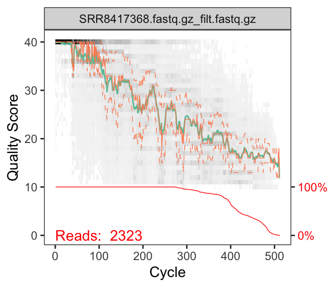

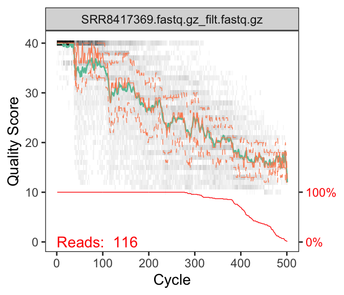

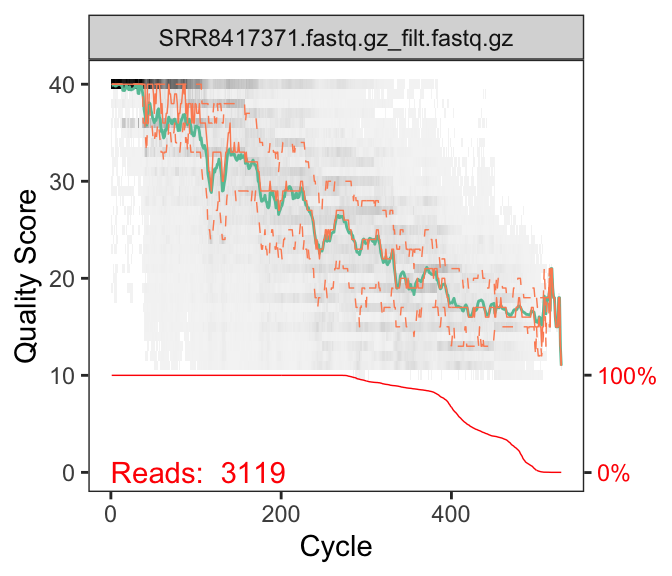

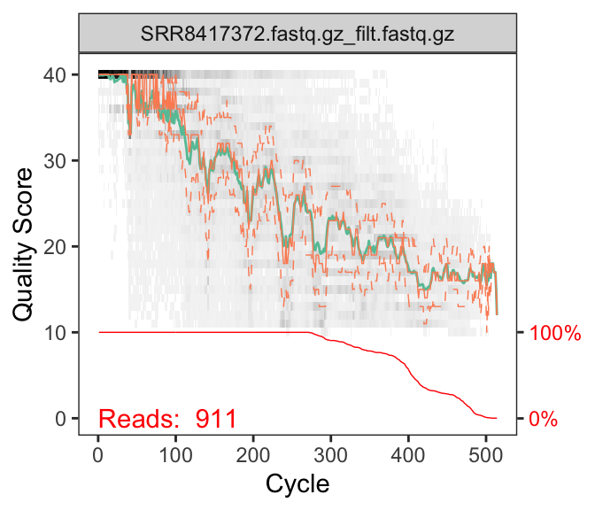

```r
# Quality profile after primer removal
for (i in 3:6){
  show(plotQualityProfile(filt1_samples[i]))
}
```

### 2. Quality filtering

Then, we perform a quality filtering of the reads.

```r
# Place filtered files in a filtered/ subdirectory
filt2_samples <- file.path(path, "filtered2", paste0(sample.names, "_filt.fastq.gz"))
# Assign names for the filtered fastq.gz files
names(filt2_samples) <- sample.names

out2 <- filterAndTrim(fwd = filt1_samples, filt = filt2_samples,
                      maxEE = 3, # reads with more than 3 expected errors (sum(10e(-Q/10))) are discarded
                      truncQ = 10, # Truncate reads at the first instance of a quality score less than or equal to truncQ.
                      minLen = 150, # Discard reads shorter than 150 bp. This is done after trimming and truncation.
                      compress=TRUE,
                      multithread = TRUE,
                      verbose=TRUE)
```

```r
out2[3:6,] # show how many reads were filtered in each file
```

```
##                                   reads.in reads.out
## SRR8417368.fastq.gz_filt.fastq.gz     2323       943
## SRR8417369.fastq.gz_filt.fastq.gz      116        50
## SRR8417371.fastq.gz_filt.fastq.gz     3119      1180
## SRR8417372.fastq.gz_filt.fastq.gz      911       381
```

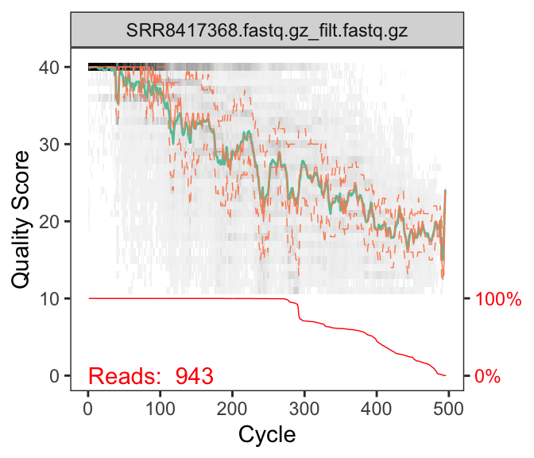

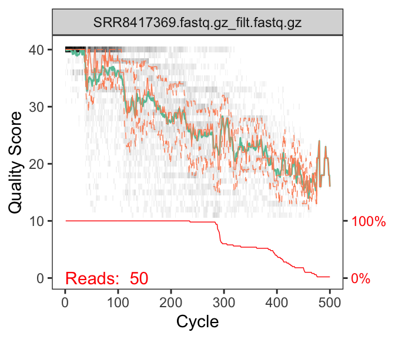

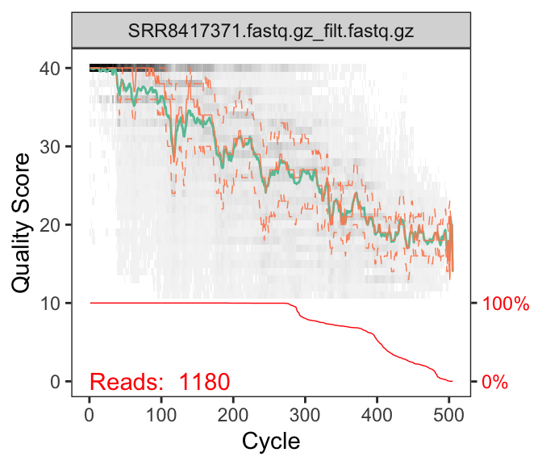

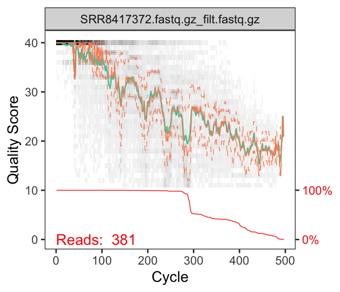

```r
# Look at quality profile of filtered files
for (i in 3:6){
  show(plotQualityProfile(filt2_samples[i]))
}
```

## LEARN ERROR RATES

Now we will build the parametric error model, to be able to infer amplicon sequence variants (ASVs) later on.

```r
err <- learnErrors(filt2_samples, multithread=TRUE, randomize = TRUE, verbose = 1)
```

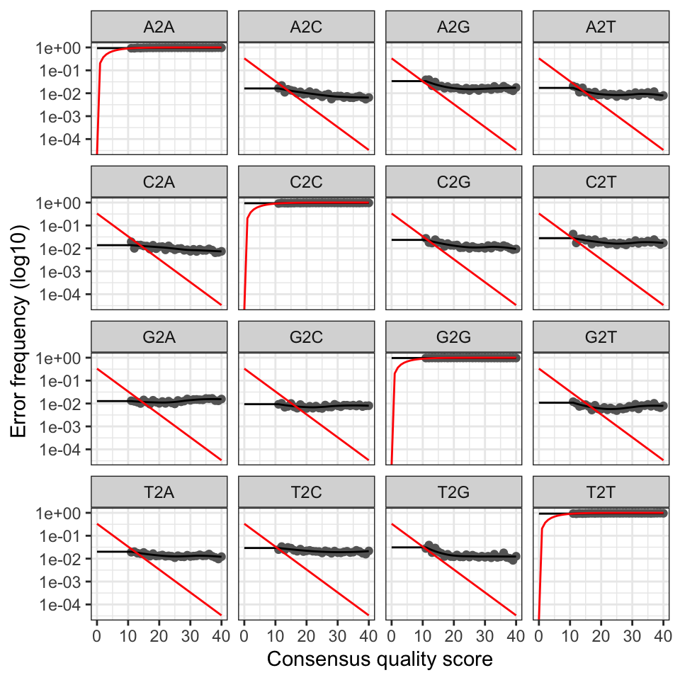

```r
plotErrors(err, nominalQ = TRUE)
```

## CONSTRUCT SEQUENCE TABLE

### 1. Infer sample composition

The *dada()* algorithm infers sequence variants based on estimated errors (previous step). Firstly, we de-replicate the reads in each sample, to reduce the computation time. De-replication is a common step in almost all modern ASV inference (or OTU picking) pipelines, but a unique feature of derepFastq is that it maintains a summary of the quality information for each dereplicated sequence in $quals.

```r
# Prepare empty vector for the infered sequences
seq_infered <- vector("list", length(sample.names))
names(seq_infered) <- sample.names

# Iterate through the 163 samples
for(sampl in sample.names) {
  cat("Processing:", sampl, "\n")
  derep <- derepFastq(filt2_samples[[sampl]]) # dereplicate the reads in the sample
  seq_infered[[sampl]] <- dada(derep, err=err, multithread=TRUE,
                               HOMOPOLYMER_GAP_PENALTY=-1, BAND_SIZE=32) # parameters for 454 sequencing recommended
}
```

```r
# Inspect the infered sequence variants from sample 1:3
for (i in 1:3){
  print(seq_infered[[i]])
  print("________________")
}
```

```
## dada-class: object describing DADA2 denoising results
## 2 sequence variants were inferred from 160 input unique sequences.
## Key parameters: OMEGA_A = 1e-40, OMEGA_C = 1e-40, BAND_SIZE = 32
## [1] "________________"
## dada-class: object describing DADA2 denoising results
## 3 sequence variants were inferred from 352 input unique sequences.
## Key parameters: OMEGA_A = 1e-40, OMEGA_C = 1e-40, BAND_SIZE = 32
## [1] "________________"
## dada-class: object describing DADA2 denoising results
## 15 sequence variants were inferred from 799 input unique sequences.
## Key parameters: OMEGA_A = 1e-40, OMEGA_C = 1e-40, BAND_SIZE = 32
## [1] "________________"
```